# Algoritmo para la estimación de la turbidez sobre el Río Paraná

# 14 Series temporales análisis dentro de la serie temporal

Notas: Los cambios que ocurren en el componente de tendencia suelen indicar disturbios (por ejemplo, incendios, ataques de insectos), mientras que los cambios en el componente estacional indican cambios fenológicos (por ejemplo, cambio en el tipo de cobertura terrestre).

Se asume que Tendecia es lineal por tramos, con puntos de quiebre. t1,t2,…..tn.

Cada tramo tiene su propia ordenada al origen y su propia pendiente.

Los puntos de quiebre estacionales pueden ocurrir en momentos diferentes a los puntos de quiebre detectados en la componente de tendencia.

En el papaer usan STL para calcular el primer punto de quibre de la componente estacional.

Para hacer el análisis de puntos de quiebre, a diferencia del paquete BFAST de R, en Python debemos utilizar 2 módulos para poder hacer el trabajo **statsmodels** y **ruptures**

Instalamos el módulo ruptures desde la consola.

- pip install ruptures

[Documentación](https://centre-borelli.github.io/ruptures-docs/install/)

## 14.1 Serie temporal de turbidez: Quiebres en tendencia y estacionalidad

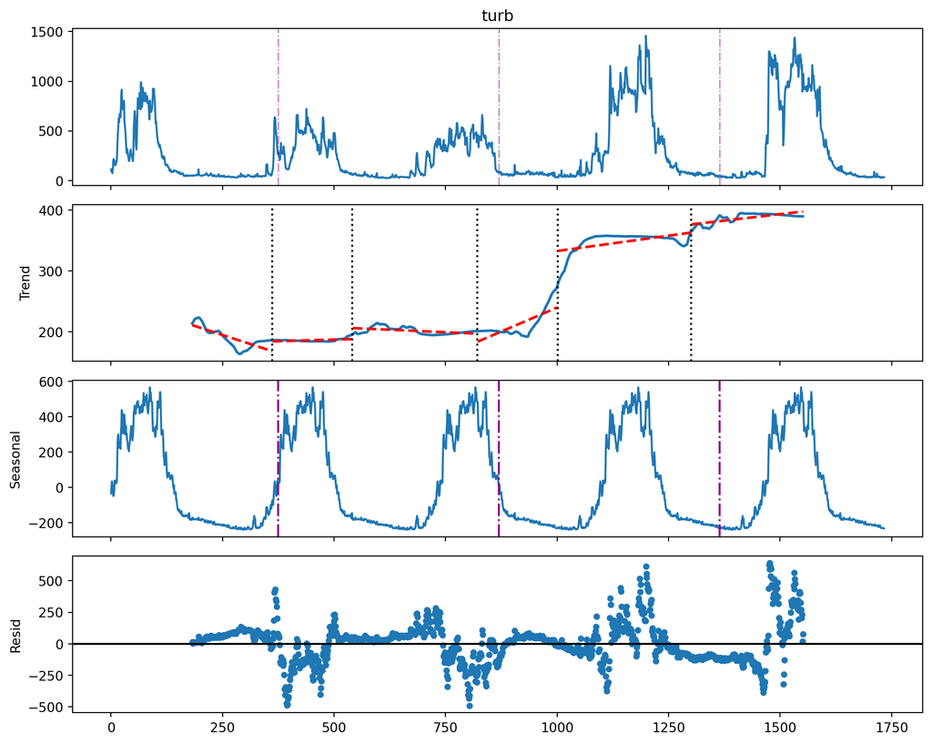

En la componente estacional (Seasonal) los quiebres significan un cambio en la forma, la duración o la intensidad del ciclo anual.

## 14.2 Serie temporal de conductividad: Quiebres en tendencia y estacionalidad

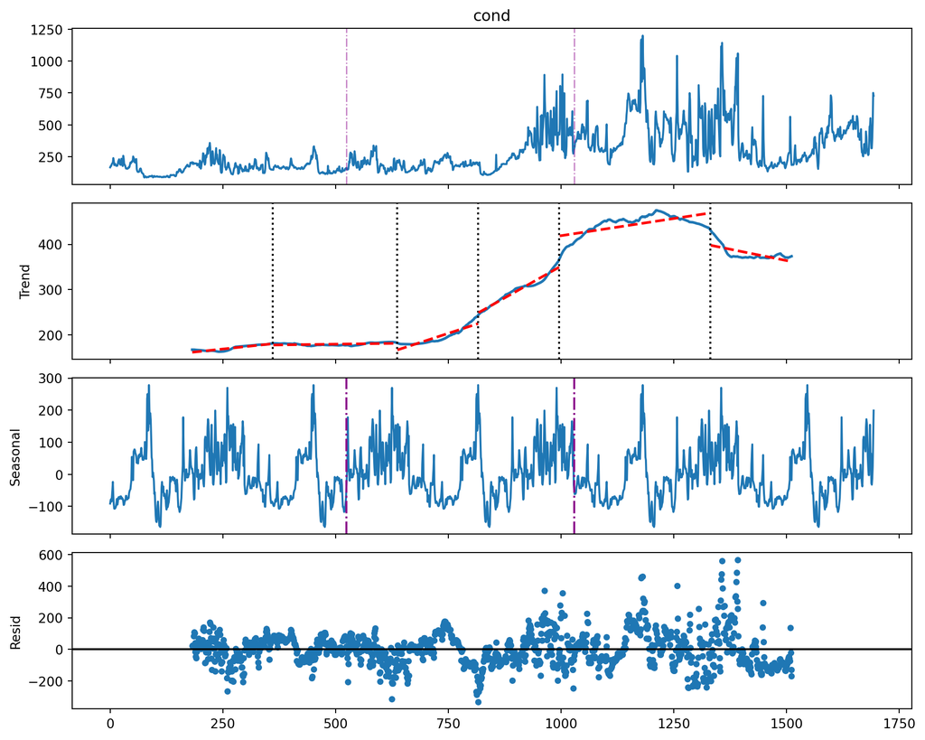

[figure not shown]

# 15 Análisis con FFT (Fast Fourier Transform)

Transformada Rápida de Fourier

de la librería SciPy, podemos usar paquete Signal processing (scipy.signal), del cual importamos en el módulo Spectral analysis.

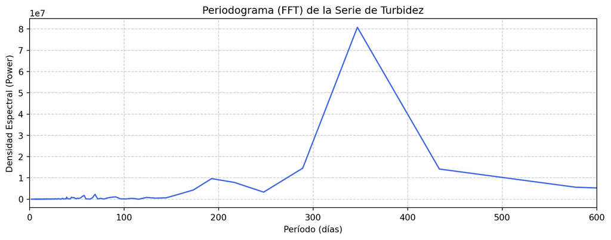

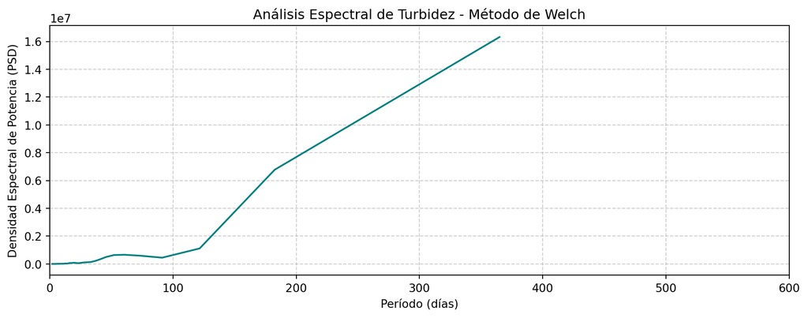

# 16 Análisis de serie temporal de turbidez, aplicación transformada de Fourier

La transformada de Fourier aplicada a una serie temporal permite pasar del dominio del tiempo (valores medidos a lo largo de los días, meses o segundos) al dominio de la frecuencia, desarmando la señal en una suma de ondas sinusoidales simples de distintas amplitudes y fases

[figure not shown]

# 17 Análisis de serie temporal de conductividad, aplicación transformada de Fourier

[figure not shown]

# 18 Análisis de serie temporal de ph, aplicación transformada de Fourier

[figure not shown]